# Introduction to Linear Regression

We will come to the formal definition later. Let us jump into a real problem.

# How many of you have visited the Yellowstone National Park?

[figure not shown]

```python
from IPython.display import YouTubeVideo
YouTubeVideo('hAzETelnBz4')
```

[video not shown]

[figure not shown]

# If you had some data, how can you predict the time of the next eruption?

## What data do you need?

```python
List of data that could help
```

```python
dot plot of INTER ERUPTION TIMES
```

```python
Simple Linear Regression
```

y is "some function" of x

y = f(x)

y = m x + c

m is the slope c is the intercept

# How to Perform a Linear Regression "fit" using Python

```python
import pandas as pd
import matplotlib.pyplot as plt

# this allows plots to appear directly in the notebook
%matplotlib inline
```

```python
# read data into a DataFrame
faithful_df = pd.read_csv('data/old_faithful.csv')
faithful_df.head()
```

|  | eruptions | waiting |
| --- | --- | --- |
| 0 | 3.600 | 79 |
| 1 | 1.800 | 54 |
| 2 | 3.333 | 74 |
| 3 | 2.283 | 62 |
| 4 | 4.533 | 85 |

# Let's plot it and see what it looks

(You should always try plotting your data to get a feel for it)

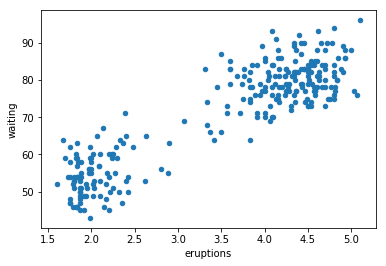

```python
# first, plot the observed data
faithful_df.plot(kind='scatter', x='eruptions', y='waiting')
```

```python
# this is the standard import if you're using "formula notation" (similar to R)
import statsmodels.formula.api as smf

# create a fitted model in one line
linear_mdl_wating = smf.ols(formula='waiting ~ eruptions', data=faithful_df).fit()

# print the coefficients
linear_mdl_wating.params
```

```
Intercept    33.474397
eruptions    10.729641
dtype: float64
```

```python
linear_mdl_wating.summary()
```

OLS Regression Results

| Dep. Variable: | waiting | R-squared: | 0.811 |
| --- | --- | --- | --- |
| Model: | OLS | Adj. R-squared: | 0.811 |
| Method: | Least Squares | F-statistic: | 1162. |
| Date: | Wed, 12 Jul 2017 | Prob (F-statistic): | 8.13e-100 |
| Time: | 20:14:23 | Log-Likelihood: | -868.38 |
| No. Observations: | 272 | AIC: | 1741. |
| Df Residuals: | 270 | BIC: | 1748. |
| Df Model: | 1 |  |  |
| Covariance Type: | nonrobust |  |  |

|  | coef | std err | t | P>\|t\| | [95.0% Conf. Int.] |
| --- | --- | --- | --- | --- | --- |
| Intercept | 33.4744 | 1.155 | 28.985 | 0.000 | 31.201 35.748 |
| eruptions | 10.7296 | 0.315 | 34.089 | 0.000 | 10.110 11.349 |

| Omnibus: | 5.492 | Durbin-Watson: | 2.543 |
| --- | --- | --- | --- |
| Prob(Omnibus): | 0.064 | Jarque-Bera (JB): | 4.683 |
| Skew: | 0.237 | Prob(JB): | 0.0962 |
| Kurtosis: | 2.567 | Cond. No. | 12.6 |

## Interpreting Model Coefficients

We can write the model as:

### waiting_time = 33.4 + 10.72 * eruption time

How do we interpret the waiting coefficient ($\beta_1$)?

A "unit" increase in eruptions time is associated with a 10.73 "unit" increase in waiting time.

An additional 1 second of previous eruption means that you have to wait 10.7 minutes longer for the next one.

### Using the Model for Prediction

Let's say that there was an eruption that lasted **3 seconds**

What would we predict for the waiting time?

```python
wait_time = 33.4 + 10.72 * 3
print("{} minutes".format(wait_time))
```

```
65.56 minutes
```

```python
# What does the R^2 Look like?

print(linear_mdl_wating.rsquared)
print(linear_mdl_wating.rsquared_adj)
```

```
0.811460760973
0.810762467495
```

### Use the Model to make predictions

Statsmodel can be used to make predictions.

**Note** It expects the inputs to come as a data frame.

```python
# you have to create a DataFrame since the Statsmodels formula interface expects it
X_newdata = pd.DataFrame({'eruptions': [1,2,3,4]})
X_newdata.head()
```

|  | eruptions |
| --- | --- |
| 0 | 1 |
| 1 | 2 |
| 2 | 3 |
| 3 | 4 |

```python
linear_mdl_wating.predict(X_newdata)
```

```
array([ 44.20403842,  54.93367981,  65.66332121,  76.3929626 ])
```

### Plotting the Least Squares Line

```python
# create a DataFrame with the minimum and maximum values of TV
X_newdata = pd.DataFrame({'eruptions': [1,2,3,4,5]})
X_newdata.head()
```

|  | eruptions |
| --- | --- |
| 0 | 1 |
| 1 | 2 |
| 2 | 3 |
| 3 | 4 |
| 4 | 5 |

```python
# make predictions for those x values and store them
preds = linear_mdl_wating.predict(X_newdata)
preds
```

```
array([ 44.20403842,  54.93367981,  65.66332121,  76.3929626 ,  87.122604  ])
```

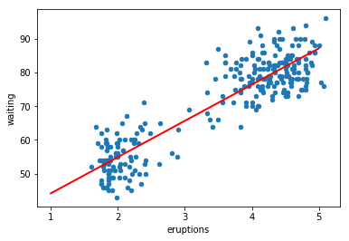

```python
faithful_df.plot(kind='scatter', x='eruptions', y='waiting')

# then, plot the least squares line
plt.plot(X_newdata, preds, c='red', linewidth=2)
```

## Is this a good fit?

```python
# read data into a DataFrame
data = pd.read_csv('http://www-bcf.usc.edu/~gareth/ISL/Advertising.csv', index_col=0)
data.head()
```

|  | TV | Radio | Newspaper | Sales |
| --- | --- | --- | --- | --- |
| 1 | 230.1 | 37.8 | 69.2 | 22.1 |
| 2 | 44.5 | 39.3 | 45.1 | 10.4 |
| 3 | 17.2 | 45.9 | 69.3 | 9.3 |
| 4 | 151.5 | 41.3 | 58.5 | 18.5 |
| 5 | 180.8 | 10.8 | 58.4 | 12.9 |

```python
# this is the standard import if you're using "formula notation" (similar to R)
import statsmodels.formula.api as smf

# create a fitted model in one line
lm = smf.ols(formula='Sales ~ TV', data=data).fit()

# print the coefficients
lm.params
```

```
Intercept    7.032594
TV           0.047537
dtype: float64
```

```python
# print a summary of the fitted model
lm.summary()
```

OLS Regression Results

| Dep. Variable: | Sales | R-squared: | 0.612 |
| --- | --- | --- | --- |
| Model: | OLS | Adj. R-squared: | 0.610 |
| Method: | Least Squares | F-statistic: | 312.1 |
| Date: | Tue, 11 Jul 2017 | Prob (F-statistic): | 1.47e-42 |
| Time: | 13:59:03 | Log-Likelihood: | -519.05 |
| No. Observations: | 200 | AIC: | 1042. |
| Df Residuals: | 198 | BIC: | 1049. |
| Df Model: | 1 |  |  |
| Covariance Type: | nonrobust |  |  |

|  | coef | std err | t | P>\|t\| | [95.0% Conf. Int.] |
| --- | --- | --- | --- | --- | --- |
| Intercept | 7.0326 | 0.458 | 15.360 | 0.000 | 6.130 7.935 |
| TV | 0.0475 | 0.003 | 17.668 | 0.000 | 0.042 0.053 |

| Omnibus: | 0.531 | Durbin-Watson: | 1.935 |
| --- | --- | --- | --- |
| Prob(Omnibus): | 0.767 | Jarque-Bera (JB): | 0.669 |
| Skew: | -0.089 | Prob(JB): | 0.716 |
| Kurtosis: | 2.779 | Cond. No. | 338. |

```python
lm.rsquared
```

```
0.61187505085007099
```

0.61187505085007099 Is that a "good" R-squared value? It's hard to say. The threshold for a good R-squared value depends widely on the domain. Therefore, it's most useful as a tool for comparing different models.